# 1.1 Hypothesis testing - practical

```r
library(tidyverse)
library(infer)
data(msleep)
```

#1. Jabberwockies sleep for around 7 hours a night, on average. Perform an appropriate statistical test to determine whether the mean sleep_total in the sampled population of animal types differs from the typical value for jabberwockies.

H0: μ(sleep_total) = 7 Ha: μ(sleep_total) ≠ 7

significance level = 0.05 (5%)

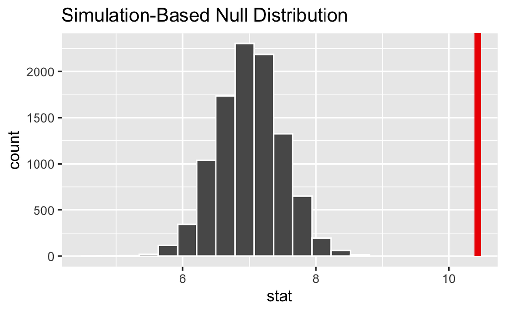

```r
# generate the null distribution, assuming Null Hypothesis is true

null_distribution <- msleep %>%
  specify(response = sleep_total) %>%
  hypothesise(null = "point", mu = 7) %>%
  generate(reps = 10000, type = "bootstrap") %>%
  calculate(stat = "mean")

# value of observed statistic, the mean(sleep_total)

observed_stat <- msleep %>%
  summarise(mean_sleep_total = mean(sleep_total))

# Visualise the null distribution

null_distribution %>%
  visualise() +
  shade_p_value(obs_stat = observed_stat$mean_sleep_total, direction = "both")
```

```r
# Calculate p-value

p_value <- null_distribution %>%
  get_p_value(obs_stat = observed_stat$mean_sleep_total, direction = "both")
```

```
Please be cautious in reporting a p-value of 0. This result is an approximation based on the number of `reps` chosen in the `generate()` step. See `?get_p_value()` for more information.
```

# Conclusion:

p_value < 0.001 and significance level = 0.05. 0.001 < 0.05 (p_value < significance level)

Reject the Null.

There is enough evidence to believe that the avarage sleep hours (mean sleep_total) in the sampled population of animals differs from the typical (7 hours) value for jabberwockies.

# 2.

Perform an appropriate statistical test to determine whether omnivores sleep for significantly longer than herbivores, on average.

- two-sample independent hypothesis test

α = 0.05

H0: μ sleep_total(omnivores) − μ sleep_total(herbivores) = 0 Ha: μ sleep_total(omnivores) − μ sleep_total(herbivores) > 0

```r
# selecting the data we want to use

msleep_filtered <- msleep %>%
  select(vore, sleep_total) %>%
  filter(vore %in% c("omni", "herbi"))

# visualise the distributions and check the sizes of both samples

msleep_filtered %>%
  group_by(vore) %>%
  summarise(n = n())
```

| vore | n |
| --- | --- |
| herbi | 32 |
| omni | 20 |

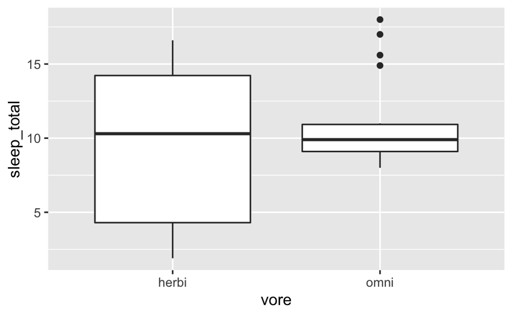

```r
msleep_filtered %>%
  ggplot(aes(y = sleep_total, x = vore)) +
  geom_boxplot()
```

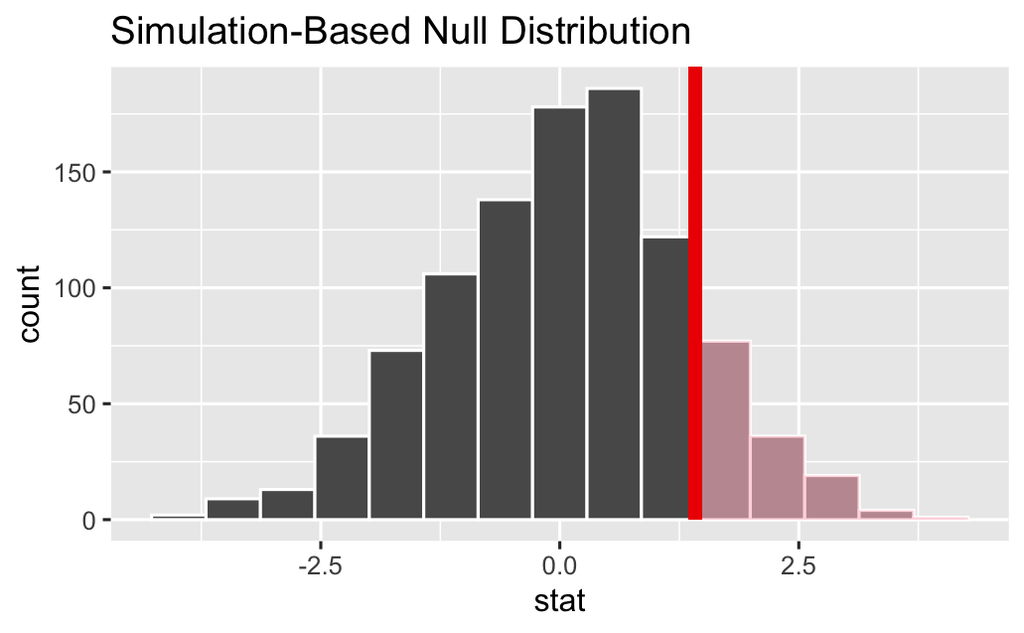

```r
# using permutation to generate the null distribution

null_distribution <- msleep_filtered %>%
  specify(sleep_total ~ vore) %>% # testing whether sleep_total varies with vore
  hypothesize(null = "independence") %>% # the null hypothesis is there is no relationship
  generate(reps = 1000, type = "permute") %>%
  calculate(stat = "diff in means", order = c("omni", "herbi"))

# calculate observed statistic

observed_stat <- msleep_filtered %>%
  specify(sleep_total ~ vore) %>%
  calculate(stat = "diff in means", order = c("omni", "herbi"))

# visualise the null distribution and where the observed statistic lies on the distribution

null_distribution %>%
  visualise() +
  shade_p_value(obs_stat = observed_stat, direction = "greater")
```

```r
# calculate p-value

p_value <- null_distribution %>%
  get_p_value(obs_stat = observed_stat, direction = "greater")

p_value
```

| p_value |
| --- |
| 0.138 |

# Conclusion

We can conclude that there is not enough evidence in our data to suggest that omnivores sleep on average for significantly longer than herbivores.

# 3

Perform an appropriate statistical test to determine whether the proportion of domesticated animal types in the population of animal types is greater than 5%.

H0: π(is_domesticated == “yes”) = 0.05 Ha: π(is_domesticated == “yes”) > 0.05

α = 0.05

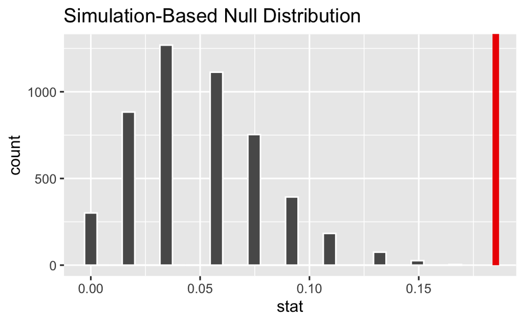

```r
# creating an is_domesticated variable for the analysis

msleep_tidy <- msleep %>%
  filter(!is.na(conservation)) %>%
  mutate(is_domesticated = if_else(conservation == "domesticated", "yes", "no"))


# generating null sampling distribution, using simulation

null_distribution <- msleep_tidy %>%
  specify(response = is_domesticated, success = "yes") %>%
  hypothesise(null = "point", p = 0.05) %>%
  generate(reps = 5000, type = "simulate") %>%
  calculate(stat = "prop")

# calculate point estimate of our sample population
observed_stat <- msleep_tidy %>%
  specify(response = is_domesticated, success = "yes") %>%
  calculate(stat = "prop")


# visualise sampling distribution

null_distribution %>%
  visualise(bins = 30)+
  shade_p_value(obs_stat = observed_stat, direction = "greater")
```

```r
# calculate p-value

p_value <- null_distribution %>%
  get_p_value(obs_stat = observed_stat, direction = "greater")
```

```
Please be cautious in reporting a p-value of 0. This result is an approximation based on the number of `reps` chosen in the `generate()` step. See `?get_p_value()` for more information.
```

```r
options(scipen = 999) # convert scientific notation to number
p_value
```

| p_value |
| --- |
| 0 |

# Conclusion

We reject the null hypothesis.

There is sufficient evidence to believe that the proportion of domesticated animal types in the population of animal types is greater than 5%.